# Ejemplo de solución ejercicio prático N°3

Poder estadístico en pruebas con medias

#### Nota:

Puesto que hay preguntas en relación a poder estadístico de pruebas con medias unilaterales (de una cola) y bilaterales (de dos colas), se presentan aquí ejemplos de solución para ambos escenarios.

## Enunciado

En una planta química hay dos máquinas que envasan detergentes industriales en bidones con un volumen de producto que sigue una distribución normal con desviación estándar de 1 litro. La ingeniera a cargo de la planta debe asegurar que los bidones se están llenando con una media de 10 litros. Pero ella tiene la sospecha de que hay desviaciones en esta media, lo que piensa confirmar usando una muestra aleatoria de 100 envases (50 de cada una de las máquinas). También cree que hay diferencia en el cumplimiento del volumen requerido entre la máquina más antigua y la más moderna, que han de andar por el 90% y 96% de los bidones, respectivamente.

## Pregunta 1 — prueba bilateral

Si la ingeniera piensa rechazar la hipótesis nula cuando la muestra presente una media menor a 9,9 litros o mayor a 10,1 litros, ¿cuál es la probabilidad de que cometa un error de tipo I?

Definimos los valores conocidos.

```r
desviacion.estandar <- 1
tamano.muestra <- 100
valor.nulo <- 10
cota.inferior <- 9.9
cota.superior <- 10.1
```

Del enunciado se desprende que se trata de una **prueba t de Student para una muestra, con hipótesis alternativa bilateral**, para la que podríamos enunciar las siguientes hipótesis.

H$_0$: el volumen medio ($\bf{\small \mu_{V}}$) de los bidones de detergente es de 10 litros ($\bf{\small \mu_{V} = 10}$ [L]).  
H$_A$: el volumen medio de los bidones es distinto de 10 litros ($\bf{\small \mu_{V} \neq 10}$ [L]).

La probabilidad de cometer un error tipo I corresponde al nivel de significación ($\alpha$), que es lo que se solicita. El nivel de significación está dado por **el área de la región de rechazo** de la distribución que deberían seguir las medias muestrales bajo la hipótesis nula. En estos casos, esta distribución usualmente sigue una distribución t, pero en este enunciado en particular también se puede usar la distribución normal dado que se conoce **la desviación estándar en la población** y podemos calcular de forma exacta el error estándar.

```r
error.estandar <- desviacion.estandar / sqrt(tamano.muestra)
```

Generemos una distribución normal en torno al valor nulo, con 5.000 valores.

```r
puntos <- 5000

x <- seq(valor.nulo - 5.2 * error.estandar, valor.nulo + 5.2 * error.estandar,
         length.out = puntos)

y <- dnorm(x, mean = valor.nulo, sd = error.estandar)
distr <- data.frame(x, y)
```

Con esta simulación, graficamos la distribución muestral.

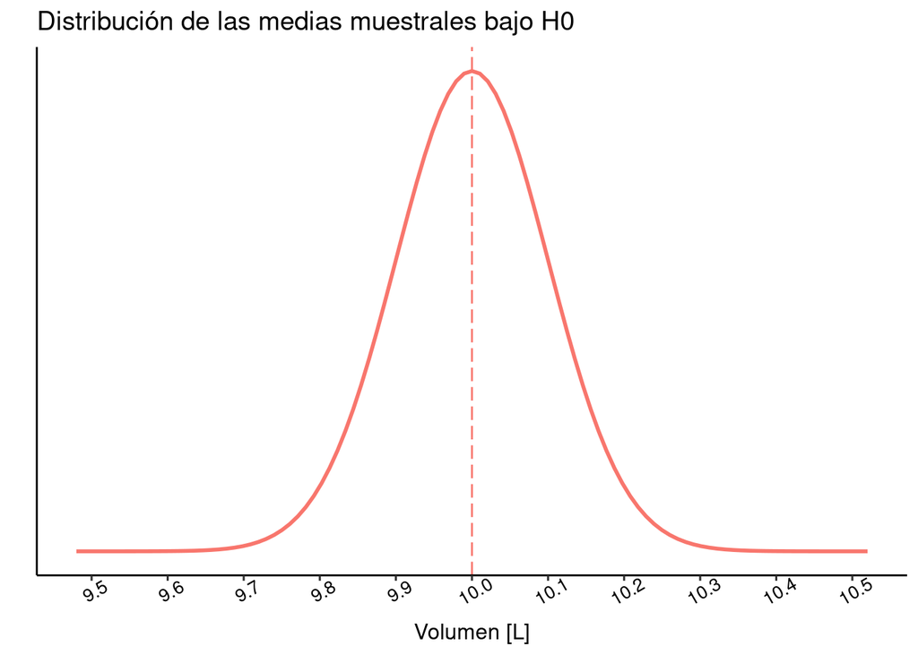

```r
library(ggpubr)

# Definimos una paleta de colores.
colores <- hcl(h = (seq(15, 255, length.out = 3)), c = 100, l = 65)

# Comenzamos por la cuadrícula con fondo blanco.
g.dist <- ggplot(data = distr, aes(x))
g.dist <- g.dist + theme_pubr()

# Agregamos la distribución normal.
g.dist <- g.dist +
          stat_function(fun = dnorm,
                        args = list(mean = valor.nulo, sd = error.estandar),
                        colour = colores[1], linewidth = 1)

# Quitamos las etiquetas y marcas del eje y.
g.dist <- g.dist + ylab("")
g.dist <- g.dist + scale_y_continuous(breaks = NULL)

# Agregamos marcas y etiquetas rotadas al eje x.
g.dist <- g.dist +
          scale_x_continuous(name = "Volumen [L]",
                             breaks = seq(round(min(x), 1), round(max(x), 1), 0.1))
g.dist <- g.dist +
          theme(axis.text.x = element_text(angle = 30, size = 10))

# Agregamos la media bajo la hipótesis nula.
g.dist <- g.dist +
          geom_vline(xintercept = valor.nulo,
                     colour = colores[1], linetype = "longdash")

# Agregamos el título.
g.dist <- g.dist + ggtitle("Distribución de las medias muestrales bajo H0")

# Finalmente Mostramos el gráfico.
print(g.dist)
```

Ahora podemos marcar las regiones de rechazo definidas por el ingeniero.

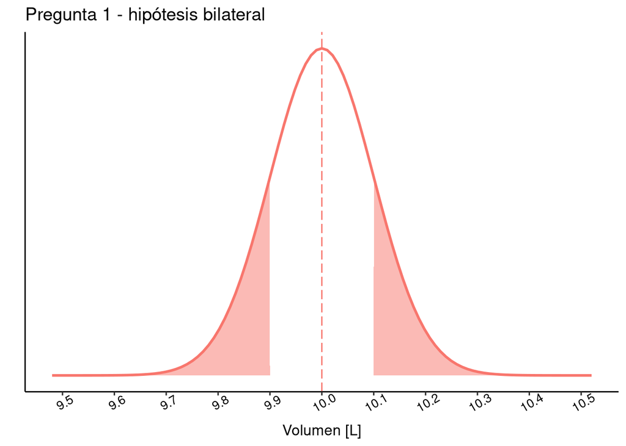

```r
# Marcamos el lado izquierdo.
g.1.bilateral <- g.dist +
                 geom_area(data = subset(distr, x < cota.inferior),
                           aes(y = y), colour = colores[1],
                           fill = colores[1], alpha = 0.5)

# Marcamos el lado derecho.
g.1.bilateral <- g.1.bilateral +
                 geom_area(data = subset(distr, x > cota.superior),
                           aes(y = y), colour = colores[1],
                           fill = colores[1], alpha = 0.5)

# Agregamos el título y mostramos el gráfico
g.1.bilateral <- g.1.bilateral + ggtitle("Pregunta 1 - hipótesis bilateral")
print(g.1.bilateral)
```

Se puede apreciar que la ingeniera definió grandes regiones de rechazo. Esperamos entonces un nivel de significación alto. Calculemos esta probabilidad (como el área de estas regiones).

```r
alfa_izquierdo <- pnorm(cota.inferior, mean = valor.nulo, sd = error.estandar,
                        lower.tail = TRUE)
alfa_derecho <- pnorm(cota.superior, mean = valor.nulo, sd = error.estandar,
                      lower.tail = FALSE)
alfa.1.bilateral <- alfa_izquierdo + alfa_derecho
```

Y mostremos el resultado en pantalla.

```r
cat("La probabilidad de cometer un error tipo I es alfa =", alfa.1.bilateral,"\n\n")
```

```
La probabilidad de cometer un error tipo I es alfa = 0.3173105
```

Interpretemos este análisis.

Con los umbrales definidos por la ingeniera para rechazar la hipótesis nula (9,9 y 10,1 litros), la probabilidad de que cometa un error de tipo I es $\alpha$=0,317.

## Pregunta 2 — prueba bilateral

Si el verdadero volumen medio de los bidones fuera de 9,95 litros, ¿cuál sería la probabilidad de que la ingeniera, que obviamente no conoce este dato, cometa un error de tipo II?

Es importante darse cuenta de que estamos trabajando con la misma prueba, solo que ahora conocemos la verdadera media (lo que no ocurre en la realidad). Para responder, construimos un gráfico de la distribución muestral con esta verdadera media que superponemos al de la hipótesis nula. Primero simulamos 5.000 valores.

```r
media.bilateral <- 9.95

x1 <- seq(media.bilateral - 5.2 * error.estandar,
          media.bilateral + 5.2 * error.estandar, length.out = puntos)

y1 <- dnorm(x1, mean = media.bilateral, sd = error.estandar)
distr1 <- data.frame(x = x1, y = y1)
```

Y graficamos la curva de esta *verdadera* distribución muestral.

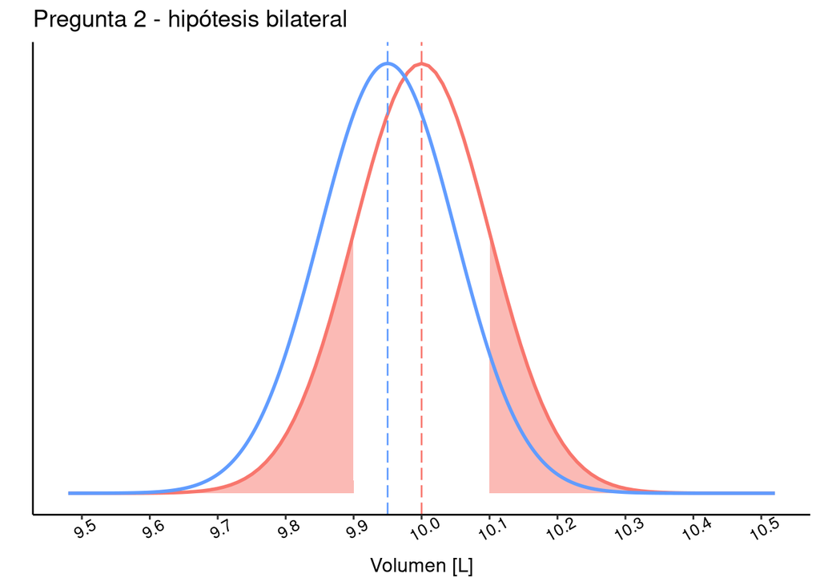

```r
g.2.bilateral <- g.1.bilateral +
                 stat_function(fun = dnorm, n = puntos,
                               args = list(mean = media.bilateral, sd = error.estandar),
                               colour = colores[3], linewidth = 1)

g.2.bilateral <- g.2.bilateral +
                 geom_vline(xintercept = media.bilateral, colour = colores[3],
                            linetype = "longdash")

g.2.bilateral <- g.2.bilateral + ggtitle("Pregunta 2 - hipótesis bilateral")
print(g.2.bilateral)
```

El error tipo II significa **no rechazar la hipótesis nula cuando esta es falsa**. En este caso, no rechazar la idea de que la media de la población es 10 [L], siendo que en realidad es 9,95 [L]. Este tipo de error ocurre si **la media muestral cae fuera de las regiones críticas** definidas por la ingeniera. Marquemos esta región.

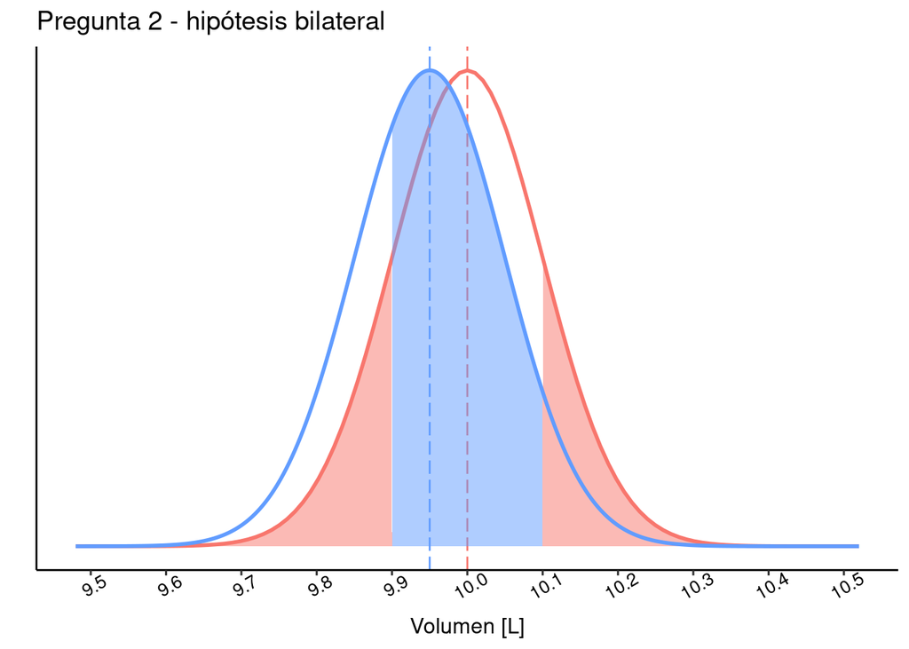

```r
g.2.bilateral <- g.2.bilateral + geom_area(
  data = subset(distr1, x >= cota.inferior & x <= cota.superior),
  aes(y = y), colour = colores[3], fill = colores[3], alpha = 0.5)
print(g.2.bilateral)
```

Es decir, se comete un error de tipo II cuando la media de la muestra sea mayor al umbral inferior y menor al umbral superior escogidas por la ingeniera. Calculemos esta probabilidad (área de la región azul).

```r
# Calcular la probabilidad de esta región (beta)
beta.superior <- pnorm(cota.superior, mean = media.bilateral,
                       sd = error.estandar, lower.tail = TRUE)

beta.inferior <- pnorm(cota.inferior, mean = media.bilateral,
                       sd = error.estandar, lower.tail = TRUE)

beta.bilateral <- beta.superior - beta.inferior
```

Y mostremos el resultado en pantalla.

```r
cat("La probabilidad de cometer un error tipo II es beta =", beta.bilateral, "\n\n")
```

```
La probabilidad de cometer un error tipo II es beta = 0.6246553
```

Ahora podemos responder.

Si la verdadera media fuera 9,95 [L], con los umbrales definidos por la ingeniera para rechazar la hipótesis nula (9,9 y 10,1 litros), la probabilidad de que cometa un error de tipo II sería $\beta$=0,625.

## Pregunta 3 — prueba bilateral

Como no se conoce el verdadero volumen medio, genere un gráfico del poder estadístico con las condiciones anteriores, pero suponiendo que el verdadero volumen medio podría variar de 9,6 a 10,4 litros.

Como es extremadamente inusual conocer la verdadera media de la población, es más realista revisar cómo cambia la probabilidad de detectar que H$_0$ es falsa para diferentes valores de la verdadera media. Esta probabilidad es lo que se conoce como **el poder estadístico** (o potencia estadística) y lo que se nos pide es un gráfico de cómo cambia a medida que se acerca o aleja del valor nulo considerado.

Para mayor facilidad, primero definimos una función que calcule el poder estadísticos para una media, un error estándar y umbrales dados.

```r
calcula_poder <- function(media, error_estandar, umbral_inf = NULL, umbral_sup = NULL) {
  poder_inf <- 0
  poder_sup <- 1

  if(!is.null(umbral_inf))
    poder_inf <- pnorm(umbral_inf, mean = media, sd = error_estandar,
                       lower.tail = TRUE)
  if(!is.null(umbral_sup))
    poder_sup <- pnorm(umbral_sup, mean = media, sd = error_estandar,
                       lower.tail = FALSE)

  poder <- poder_inf + poder_sup
  return(poder)
}
```

#### Nota:

Generamos algunos puntos en el rango indicado en la pregunta para poder graficar, considerando el error estándar y umbrales definidos en el enunciado.

```r
x3 <- seq(9.6, 10.4, 0.01)
y3 <- sapply(x3, calcula_poder, error_estandar = error.estandar,
             umbral_inf = cota.inferior, umbral_sup = cota.superior)
distr3 <- data.frame(x = x3, y = y3)
```

Ahora generamos el gráfico con la curva de poder.

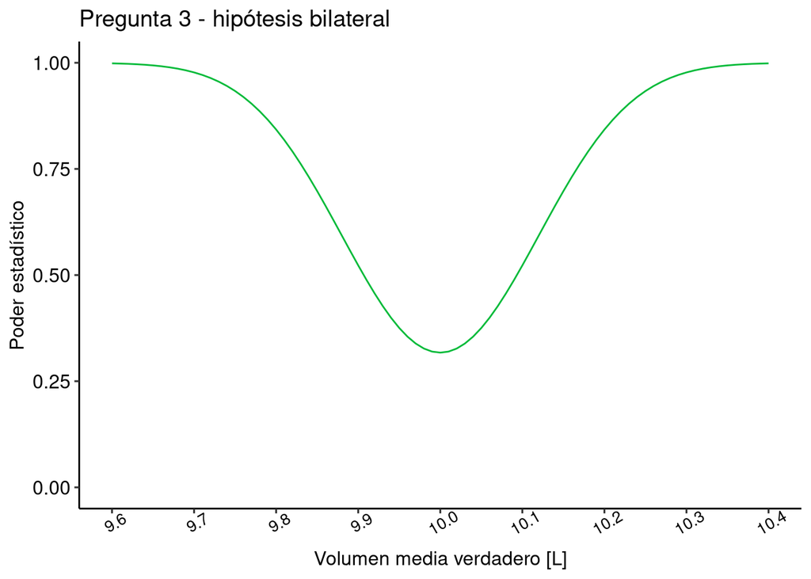

```r
g.3.bilateral <- ggplot(distr3, aes(x, y)) + ylim(c(0, 1))
g.3.bilateral <- g.3.bilateral +
                 scale_x_continuous(name = "Volumen media verdadero [L]",
                                    breaks = seq(round(min(x3), 1), round(max(x3), 1), 0.1))
g.3.bilateral <- g.3.bilateral + geom_line(colour = colores[2])
g.3.bilateral <- g.3.bilateral + ylab("Poder estadístico")
g.3.bilateral <- g.3.bilateral + theme_pubr()
g.3.bilateral <- g.3.bilateral +
                 theme(axis.text.x = element_text(angle = 30, size = 10))
g.3.bilateral <- g.3.bilateral + ggtitle("Pregunta 3 - hipótesis bilateral")

print(g.3.bilateral)
```

En el gráfico se puede ver la curva de poder que resulta, la cual se acerca a uno a medida que la verdadera media se aleja del valor de la hipótesis nula (10 [L]), mientras que disminuye a medida que se acerca a este valor, donde alcanza su valor mínimo que corresponde a la probabilidad de rechazar H$_0$ cuando, después de todo, es verdadera. Es decir, este valor es la probabilidad de cometer un error de tipo I ($\alpha$).

## Pregunta 4 — prueba bilateral

Considerando la suposición de que el verdadero volumen medio de los bidones es de 9,95 litros, ¿cuántos bidones deberían revisarse para conseguir un poder estadístico de 0,9 y un nivel de significación de 0,05?

Aquí se pregunta por el **tamaño de la muestra** para conseguir los valores para los factores de la prueba dados tanto explícitamente ($\alpha$= 0,05 y $(1-\beta)$=0,90) como implícitamente, que en este caso es el **tamaño del efecto**: $\delta = \lvert \mu_{V}-\mu_{0} \rvert =$ $\lvert$ 9,95 $-$ 10,00 $\rvert$ $=$ 0,05.

Recordemos que el paquete `pwr` contiene funciones para responder este tipo de preguntas, pero que utilizan el tamaño del efecto expresado como la $d$ de Cohen. En este caso:

```r
efecto.bilateral <- (media.bilateral - valor.nulo) / desviacion.estandar
```

Si consideramos que estamos realizando una prueba Z, se puede usar la función para este tipo.

```r
library(pwr)

poder.z.bilateral <- pwr.norm.test(d = efecto.bilateral, sig.level = 0.05,
                                   power = 0.90, alternative = "two.sided")
print(poder.z.bilateral)
```

```
     Mean power calculation for normal distribution with known variance

              d = 0.05
              n = 4202.968
      sig.level = 0.05
          power = 0.9
    alternative = two.sided
```

```r
tamano.z.bilateral <- ceiling(poder.z.bilateral[["n"]])
cat("El tamaño de la muestra para una prueba Z debe ser n =",
    tamano.z.bilateral, "\n\n")
```

```
El tamaño de la muestra para una prueba Z debe ser n = 4203
```

Si en vez consideramos una prueba t de Student, usamos la función para esa prueba.

```r
poder.t1.bilateral <- pwr.t.test(d = efecto.bilateral, sig.level = 0.05,
                                 power = 0.90, type = "one.sample",
                                 alternative = "two.sided")
print(poder.t1.bilateral)
```

```
     One-sample t test power calculation

              n = 4204.889
              d = 0.05
      sig.level = 0.05
          power = 0.9
    alternative = two.sided
```

```r
tamano.t1.bilateral <- ceiling(poder.t1.bilateral[["n"]])
cat("El tamaño de la muestra para una prueba t debe ser n =",
    tamano.t1.bilateral, "\n\n")
```

```
El tamaño de la muestra para una prueba t debe ser n = 4205
```

Otra alternativa es usar la función `power.t.test()` (disponible en el *core* de R) que considera el tamaño del efecto expresado en la escala de la variable ($\delta$).

```r
diferencia.bilateral <- media.bilateral - valor.nulo
poder.t2.bilateral <- power.t.test(delta = diferencia.bilateral,
                                   sd = desviacion.estandar,
                                   sig.level = 0.05, power = 0.90,
                                   type = "one.sample",
                                   alternative = "two.sided")
print(poder.t2.bilateral)
```

```
     One-sample t test power calculation

              n = 4204.89
          delta = 0.05
             sd = 1
      sig.level = 0.05
          power = 0.9
    alternative = two.sided
```

```r
tamano.t2.bilateral <- ceiling(poder.t2.bilateral[["n"]])
cat("El tamaño de la muestra para una prueba t debe ser n =",
    tamano.t2.bilateral, "\n\n")
```

```
El tamaño de la muestra para una prueba t debe ser n = 4205
```

Podemos ver que las alternativas para la prueba t de Student llevan al mismo resultado, mientras que usando una prueba Z se llega a un número muy similar. Escribamos la conclusión considerando esta última prueba.

Suponiendo que el verdadero volumen medio de los bidones es de 9,95, se necesita una muestra de al menos 4.203 bidones para conseguir un poder estadístico de 0,9 y un nivel de significación de 0,05. Lo lógico, si ambas máquinas se usan con igual productividad, sería obtener muestras de 2.102 bidones de la máquina antigua e igual número de bidones de la máquina más moderna.

## Pregunta 5 — prueba bilateral

¿Alcanzaría esta muestra para detectar la diferencia que la ingeniera sospecha que existe entre las dos máquinas de la planta con las mismas probabilidades de cometer errores?

Primero debemos notar que esta pregunta considera que la ingeniera sospecha que existe una diferencia en la tasa de cumplimiento del volumen requerido entre las dos máquinas de la planta. Es decir, ahora vamos a considerar las siguientes hipótesis.

H$_0$: la tasa de bidones que cumplen el volumen requerido de 10 [L] que obtiene la máquina antigua ($\bf{\small p_{\mathrm{antigua}}}$) es la misma que consigue la máquina moderna ($\bf{\small p_{\mathrm{moderna}}}$); es decir $\bf{\small p_{\mathrm{antigua}} - p_{\mathrm{antigua}} = 0}$.  
H$_A$: las tasas de bidones que cumplen el volumen requerido que obtienen las máquinas de la planta son distintas; es decir $\bf{\small p_{\mathrm{antigua}} - p_{\mathrm{antigua}} \ne 0}$.

Aquí se pregunta por el **tamaño de la muestra** para mantener las probabilidades de cometer errores de la pregunta anterior ($\alpha$= 0,05 y $(1-\beta)$=0,90), pero ahora para contrastar estas nuevas hipótesis.

Para responder la duda de la ingeniera podemos seguir diferentes caminos:

1. usando el tamaño del efecto sospechado por la ingeniera, el tamaño de la muestra calculado en la pregunta anterior y fijando el nivel de significación, obtener la potencia de la prueba y verificar si es igual o mayor al 90% solicitado;
2. análogo a lo anterior, pero fijando la potencia y calculando el nivel de significación conseguido para comprobar si cumple el 5% solicitado; o
3. fijar los factores de la prueba y calcular el tamaño de la muestra necesitado, para compararlo con el tamaño requerido para la pregunta anterior.

Aquí seguiremos la tercera estrategia.

```r
# Obtenemos el tamaño del efecto
p.antigua <- 0.90
p.moderna <- 0.96
p.h <- ES.h(p.antigua, p.moderna)

# Obtenemos los tamaños de las muestras
poder.2p <- pwr.2p.test(h = p.h, sig.level = 0.05, power = 0.90, alternative = "two.sided")
print(poder.2p)
```

```
     Difference of proportion power calculation for binomial distribution (arcsine transformation)

              h = 0.2407853
              n = 362.4651
      sig.level = 0.05
          power = 0.9
    alternative = two.sided

NOTE: same sample sizes
```

```r
tamano.2p <- ceiling(poder.2p[["n"]])
mje <- paste0("El tamaño de las muestras para una prueba de la diferencia\n",
              "de dos proporciones independientes n =")
cat(mje, tamano.2p, "\n\n")
```

```
El tamaño de las muestras para una prueba de la diferencia
de dos proporciones independientes n = 363
```

Podemos concluir fácilmente:

Para resolver la duda sobre la igualdad o diferencia de las tasas de cumplimiento del llenado de bidones por las dos máquinas de la planta, se necesitarían muestras de 363 bidones de cada una para conseguir un poder estadístico de 90% y un nivel de significación del 5% considerando una diferencia hipotética de 6%.

De este modo, las muestras de 2.102 bidones de cada máquina requerida para responder la pregunta anterior serían más que suficientes en este caso.

## Pregunta 1 — prueba unilateral

Si la ingeniera está segura de que el verdadero volumen medio no puede ser inferior a 10 litros y piensa rechazar la hipótesis nula cuando la muestra presente una media mayor a 10,1 litros, ¿cuál es la probabilidad de que cometa un error de tipo I?

Definimos los valores conocidos.

```r
desviacion.estandar <- 1
tamano.muestra <- 100
valor.nulo <- 10
cota.inferior <- NULL
cota.superior <- 10.1
```

Ahora trabajamos con una **prueba t de Student para una muestra con hipótesis alternativa unilateral**, para la que se puede enunciar las siguientes hipótesis.

H$_0$: el volumen medio ($\bf{\small \mu_{V}}$) de los bidones de detergente es de 10 litros ($\bf{\small \mu_{V} = 10}$ [L]).  
H$_A$: el volumen medio de los bidones es mayor a 10 litros ($\bf{\small \mu_{V} > 10}$ [L]).

Como vimos en el caso de una prueba bilateral, nos preguntan por la probabilidad de cometer un error tipo I que corresponde al nivel de significación $\alpha$, el cual está dado por el área de la región de rechazo de la distribución que deberían seguir las medias muestrales bajo la hipótesis nula. Como conocemos la desviación estándar de la población, usemos una vez más la distribución normal (prueba Z).

Tomando como base el gráfico de la distribución normal que hicimos para el caso bilateral, ahora marcamos la única región de rechazo definida por la ingeniera.

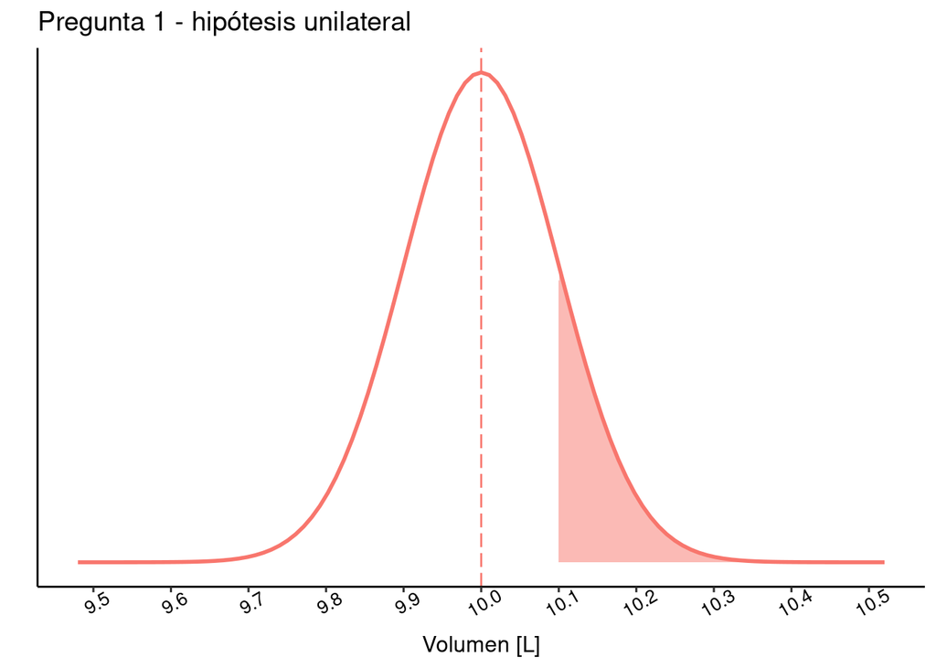

```r
g.1.unilateral <- g.dist +
                  geom_area(data = subset(distr, x > cota.superior),
                            aes(y = y), colour = colores[1],
                            fill = colores[1], alpha = 0.5)

g.1.unilateral <- g.1.unilateral +
                  ggtitle("Pregunta 1 - hipótesis unilateral")

print(g.1.unilateral)
```

Calculemos la probabilidad asociada a esta región de rechazo que corresponde a su área.

```r
# Calcular la probabilidad de la región de rechazo.
alfa.1.unilateral <- pnorm(cota.superior, mean = valor.nulo,
                           sd = error.estandar, lower.tail = FALSE)

cat("La probabilidad de cometer un error tipo I es alfa =", alfa.1.unilateral, "\n\n")
```

```
La probabilidad de cometer un error tipo I es alfa = 0.1586553
```

Interpretemos lo obtenido.

Considerando la que la ingeniera va a rechazar la hipótesis nula cuando la muestra presente una media mayor a 10,1 litros, la probabilidad de que cometa un error de tipo I es $\alpha=$ 0,159.

## Pregunta 2 — prueba unilateral

Si el verdadero volumen medio de los bidones fuera de 10,05 litros, ¿cuál sería la probabilidad de que la ingeniera, que obviamente no conoce este dato, cometa un error de tipo II?

Para responder, superponemos al gráfico anterior (hipótesis nula) la curva de la distribución muestral con esta verdadera media. Simulamos valores y graficamos la curva.

```r
media.unilateral <- 10.05
x2 <- seq(media.unilateral - 5.2 * error.estandar,
          media.unilateral + 5.2 * error.estandar, length.out = puntos)

y2 <- dnorm(x2, mean = media.unilateral, sd = error.estandar)
distr2 <- data.frame(x = x2, y = y2)

g.2.unilateral <- g.1.unilateral +
                  stat_function(fun = dnorm, n = puntos,
                                args = list(mean = media.unilateral, sd = error.estandar),
                                colour = colores[3], linewidth = 1)

g.2.unilateral <- g.2.unilateral +
                  geom_vline(xintercept = media.unilateral,
                             colour = colores[3],
                             linetype = "longdash")
```

Recordando que el error tipo II significa **no rechazar la hipótesis nula cuando esta es falsa**, lo que en este caso se traduce no rechazar la idea de que la media de la población es 10 [L], siendo que en realidad es 10,05 [L]. Marquemos la región que incluya **las medias muestrales que caen fuera de la región crítica** definida por el ingeniero.

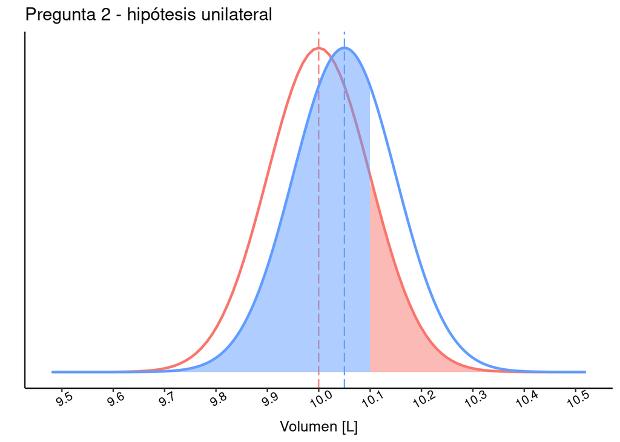

```r
g.2.unilateral <- g.2.unilateral +
                  geom_area(data = subset(distr2, x <= cota.superior),
                            aes(y = y), colour = colores[3],
                            fill = colores[3], alpha = 0.5)

g.2.unilateral <- g.2.unilateral + ggtitle("Pregunta 2 - hipótesis unilateral")
print(g.2.unilateral)
```

Calculemos esta probabilidad.

```r
# Calcular la probabilidad de esta región (beta)
beta.unilateral <- pnorm(cota.superior, mean = media.unilateral,
                         sd = error.estandar, lower.tail = TRUE)

cat("La probabilidad de cometer un error tipo II es beta =", beta.unilateral,
    "\n\n")
```

```
La probabilidad de cometer un error tipo II es beta = 0.6914625
```

Respondemos la pregunta.

Con un valor para la verdadera media de 10.05 [L] y el umbral definido por la ingeniera para rechazar la hipótesis nula (10,1 litros), la probabilidad de cometer un error de tipo II sería $\beta$=0,691.

## Pregunta 3 — prueba unilateral

Tal como en el caso bilateral nos piden la curva del cambio de la probabilidad de detectar que H$_0$ es falsa (es decir, el poder estadístico) para diferentes valores de la verdadera media.

Usaremos la función ya presentada que calcula el poder.

Generamos algunos puntos en el rango indicado en la pregunta para poder graficar, considerando el error estándar y el umbral definido en el enunciado.

```r
x4 <- seq(9.75, 10.25, 0.01)
y4 <- sapply(x4, calcula_poder, error_estandar = error.estandar,
             umbral_inf = cota.inferior, umbral_sup = cota.superior)
distr4 <- data.frame(x = x4, y = y4)
```

Ahora generamos el gráfico con la curva de poder.

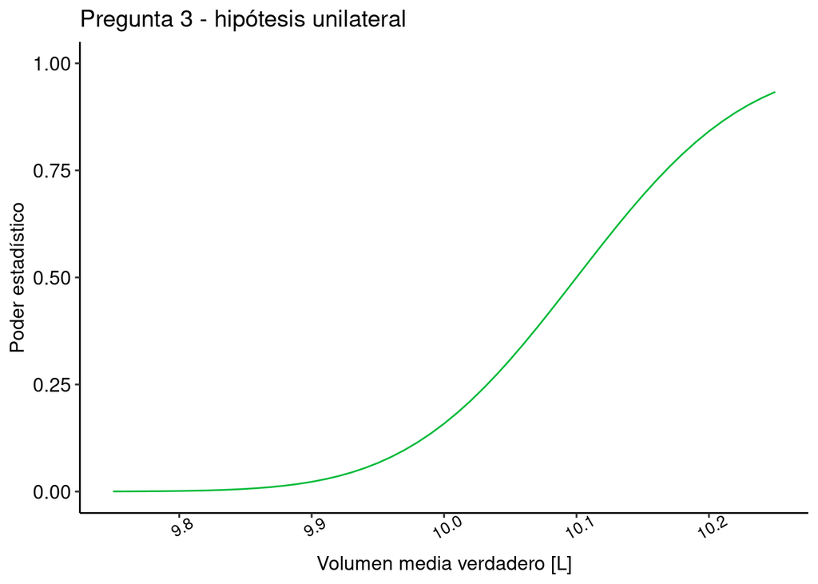

```r
g.3.unilateral <- ggplot(distr4, aes(x, y)) + ylim(c(0, 1))
g.3.unilateral <- g.3.unilateral + geom_line(colour = colores[2])
g.3.unilateral <- g.3.unilateral + ylab("Poder estadístico")
g.3.unilateral <- g.3.unilateral + xlab("Volumen media verdadero [L]")
g.3.unilateral <- g.3.unilateral + theme_pubr()
g.3.unilateral <- g.3.unilateral +
                  theme(axis.text.x = element_text(angle = 30, size = 10))
g.3.unilateral <- g.3.unilateral + ggtitle("Pregunta 3 - hipótesis unilateral")

print(g.3.unilateral)
```

En el gráfico se puede ver la curva de poder que resulta, la que es muy cercana a cero cuando es menor que el valor nulo (puesto que esto fue considerado como imposible por la ingeniera), pasa por el valor de $\alpha$ cuando la verdadera media coincide con la hipótesis nula (10 [L]), para acercarse al valor uno mientras más se aleja a la derecha de este valor.

## Pregunta 4 — prueba unilateral

Aquí tenemos las mismas alternativas que para la prueba bilateral considerando $\alpha$= 0,05, $(1-\beta)$=0,90 y $\delta = \lvert \mu_{V}-\mu_{0} \rvert =$ $\lvert 10,50-10,00\rvert=0,05$.

Calculemos el tamaño del efecto expresado como la $d$ de Cohen. En este caso:

```r
diferencia.unilateral <- media.unilateral - valor.nulo
efecto.unilateral <- diferencia.unilateral / desviacion.estandar
```

Primero consideremos una prueba Z.

```r
poder.z.unilateral <- pwr.norm.test(d = efecto.unilateral, sig.level = 0.05,
                                    power = .9, alternative = "greater")
print(poder.z.unilateral)
```

```
##
##      Mean power calculation for normal distribution with known variance
##
##               d = 0.05
##               n = 3425.539
##       sig.level = 0.05
##           power = 0.9
##     alternative = greater
```

Consideramos una prueba t de Student usando el paquete `pwr`.

```r
poder.t1.unilateral <- pwr.t.test(d = efecto.unilateral, sig.level = 0.05,
                                 power = 0.9, type = "one.sample",
                                 alternative = "greater")
print(poder.t1.unilateral)
```

```
##
##      One-sample t test power calculation
##
##               n = 3426.892
##               d = 0.05
##       sig.level = 0.05
##           power = 0.9
##     alternative = greater
```

Finalmente comprobamos la alternativa con el tamaño del efecto expresado en como $\delta$.

```r
poder.t2.unilateral <- power.t.test(delta = diferencia.unilateral,
                                    sd = desviacion.estandar,
                                    sig.level = 0.05, power = 0.9,
                                    type = "one.sample",
                                    alternative = "one.sided")
print(poder.t2.unilateral)
```

```
##
##      One-sample t test power calculation
##
##               n = 3426.892
##           delta = 0.05
##              sd = 1
##       sig.level = 0.05
##           power = 0.9
##     alternative = one.sided
```

Confirmamos que las alternativas para la prueba t de Student llevan al mismo resultado, muy similar al que se llega usando una prueba Z, Escribamos la conclusión con esta última prueba.

Suponiendo que el verdadero volumen medio de los bidones es de 10,05, se necesita una muestra de al menos 3.426 bidones (1.713 de cada máquina) para conseguir una prueba Z con un poder estadístico de 0,9 y un nivel de significación de 0,05.

## Pregunta 5 — prueba unilateral

¿Alcanzaría esta muestra para detectar que la tasa de cumplimiento de la máquina más moderna es mejor que la alcanzada por la máquina más antigua?

Como para el caso bilateral, esta pregunta considera una posible diferencia en la tasa de cumplimiento del volumen requerido entre las dos máquinas de la planta, aunque esta vez solamente consideramos la posibilidad de que esta tasa es mayor en la máquina más moderna. Las hipótesis serían:

H$_0$: la tasa de bidones que cumplen el volumen requerido de 10 [L] que obtiene la máquina antigua ($\bf{\small p_{\mathrm{antigua}}}$) es la misma que consigue la máquina moderna ($\bf{\small p_{\mathrm{moderna}}}$); es decir $\bf{\small p_{\mathrm{antigua}} - p_{\mathrm{antigua}} = 0}$.  
H$_A$: las tasas de bidones que cumplen el volumen requerido que obtienen la máquina antigua es menor que la obtenida por la máquina moderna; es decir $\bf{\small p_{\mathrm{antigua}} - p_{\mathrm{antigua}} < 0}$.

Aquí también nos interesa conocer el **tamaño de la muestra** que permitiría mantener las probabilidades de cometer errores de la pregunta anterior ($\alpha$= 0,05 y $(1-\beta)$=0,90), pero ahora para contrastar estas nuevas hipótesis.

Siguiendo la lógica usada en el caso bilateral, podemos ejecutar el siguiente código:

```r
# Obtenemos el tamaño del efecto
p.antigua <- 0.90
p.moderna <- 0.96
p.h <- ES.h(p.antigua, p.moderna)

# Obtenemos los tamaños de las muestras
poder.2p <- pwr.2p.test(h = p.h, sig.level = 0.05, power = 0.90, alternative =  "less")
print(poder.2p)
```

```
     Difference of proportion power calculation for binomial distribution (arcsine transformation)

              h = -0.2407853
              n = 295.4195
      sig.level = 0.05
          power = 0.9
    alternative = less

NOTE: same sample sizes
```

```r
tamano.2p <- ceiling(poder.2p[["n"]])
mje <- paste0("El tamaño de las muestras para una prueba unilateral de la\n",
              "diferencia de dos proporciones independientes es n =")
cat(mje, tamano.2p, "\n\n")
```

```
El tamaño de las muestras para una prueba unilateral de la
diferencia de dos proporciones independientes es n = 296
```

Notemos que la única diferencia con el código usado en el caso bilateral es que indicamos que la hipótesis alternativa solamente considera la cola inferior (`alternative = less`). Interpretemos el resultado.

Para contrastar las hipótesis sobre las tasas de cumplimiento del llenado de bidones por parte de las dos máquinas de la planta, se necesitarían muestras de 296 bidones de cada una para conseguir un poder estadístico de 90% y un nivel de significación del 5% considerando una diferencia hipotética de 6%.

De este modo, las muestras de 1.713 bidones de cada máquina requerida para responder la pregunta anterior serían más que suficientes para esta prueba.